# biasratio 实战演示：用阴性对照量化观察性效应估计中的偏倚

以心力衰竭指南导向治疗的一项（示例性）阴性对照研究为例

Author

Zeng Zhechun

Published

September 5, 2026

# 1 概述

在观察性研究中，一个统计学上显著的关联并不等于因果效应。经验校准（empirical calibration，Schuemie 等 2014）借助阴性对照结局（negative control outcomes）回答”残余系统性偏倚能否解释你的点估计”，通过校准 p 值给出二元判定。但 p 值把偏倚的”大小”与估计的”精度”混在一起，且对偏倚相对于效应存活量的”占比”只字未提。

`biasratio` 用一对等价指标把二者分开。主指标是**偏倚分数（bias attribution fraction，BAF）**，即经校准后存活信号中可归因于系统性偏倚的比例，取值在 0 到 1 之间：

$$\mathrm{BAF} = \frac{|\mu_B|}{|\mu_B| + |\log RR_{\text{calibrated}}|}
= \frac{|\text{系统性偏倚}|}{|\text{偏倚}| + |\text{校准后存活的效应}|}$$

辅助指标**偏倚效应比（bias-effect ratio，BER）**以无界比值表达同一信息：$\mathrm{BER} = \mathrm{BAF}/(1-\mathrm{BAF})$。

- BAF > 0.5（BER > 1）：偏倚占校准信号的一半以上，称为 *bias-dominated*（偏倚主导），该”效应”更可能是假象。
- 1/3 ≤ BAF ≤ 0.5（0.5 ≤ BER ≤ 1）：偏倚与信号相当，称为 *mixed*（混杂），需谨慎解读。
- BAF < 1/3（BER < 0.5）：校准信号明显超过偏倚，称为 *effect-dominated*（效应主导），该关联通过了偏倚审计。

本演示文档用一套**示例性**阴性对照研究数据，按”数据准备 → 函数调用 → 结果解读”的顺序，逐一演示 `biasratio` 的全部导出函数，并对每个函数给出可运行代码、真实输出（尤其是可视化）和详细解读。所有数值均由代码实时算出，读者可直接复现。

> 说明：本文档的数据为演示而构造，基于某真实研究校准出的经验零假设（μB = −0.20，σB = 0.07），并非真实患者数据。它用于展示整套方法，不代表任何具体临床试验的结果。

# 2 示例数据集：一项心衰阴性对照研究（数据准备）

研究问题：在射血分数降低的心力衰竭（HFrEF）患者中，指南导向的药物治疗（guideline-directed medical therapy，GDMT，含 β 受体阻滞剂达标 + 肾素血管紧张素系统抑制剂 + 盐皮质激素受体拮抗剂）能否改善 1 年全因死亡？

我们用两个治疗策略作为主估计（primary estimate），并用 12 个**阴性对照结局**来刻画该队列中普遍的系统性偏倚方向。阴性对照结局是那些与暴露（GDMT 使用）共享混杂结构、但不可能被 GDMT 因果影响的并发症或事件。

下面在 R 中构造这套数据。经验零假设来自真实校准研究：系统性偏倚均值 μB = −0.20（保护性方向），标准差 σB = 0.07。我们据此从正态分布抽取 12 个阴性对照的 log 风险比，并给出两个主估计。

```r
library(biasratio)

# 固定随机种子，保证阴性对照与 bootstrap 结果可复现
set.seed(20260905)

muB   <- -0.20   # 系统性偏倚均值（保护性方向）
sigmaB <- 0.07   # 系统性偏倚标准差

# 12 个阴性对照结局（与 GDMT 使用共享混杂，但不受 GDMT 因果影响）
nc_names <- c(
  "Hyperlipidemia", "Anemia", "Acute kidney injury", "Atrial fibrillation",
  "Pneumonia", "Hypotension", "Tachycardia", "Fluid overload",
  "COPD exacerbation", "Sepsis", "Venous thrombosis", "Hypoglycemia"
)

# 从经验零假设抽取 12 个阴性对照的 logRR 与 SE
nc_logRr   <- rnorm(12, muB, sigmaB)
nc_seLogRr <- round(runif(12, 0.04, 0.07), 4)

# 两个主估计（治疗策略）
# 策略 A：β 受体阻滞剂达到 ≥50% 目标剂量（健康依从者偏倚，校准后效应近 0）
t1_logRr <- -0.18
t1_se    <- 0.045
# 策略 B：完整 GDMT（≥2/3 类的目标剂量），真实信号但受偏倚污染
t2_logRr <- -0.50
t2_se    <- 0.050

# 整理成数据框便于查看
nc_df <- data.frame(
  negative_control = nc_names,
  logRR = round(nc_logRr, 4),
  seLogRR = nc_seLogRr,
  stringsAsFactors = FALSE
)
knitr::kable(nc_df, digits = 4, caption = "12 个阴性对照结局的 log 风险比与标准误")
```

12 个阴性对照结局的 log 风险比与标准误

| negative_control | logRR | seLogRR |
| --- | --- | --- |
| Hyperlipidemia | -0.1499 | 0.0581 |
| Anemia | -0.2037 | 0.0564 |
| Acute kidney injury | -0.2911 | 0.0575 |
| Atrial fibrillation | -0.1340 | 0.0434 |
| Pneumonia | -0.1789 | 0.0540 |
| Hypotension | -0.2213 | 0.0592 |
| Tachycardia | -0.1320 | 0.0639 |
| Fluid overload | -0.3204 | 0.0617 |
| COPD exacerbation | -0.2996 | 0.0541 |
| Sepsis | -0.1391 | 0.0649 |
| Venous thrombosis | -0.1677 | 0.0622 |
| Hypoglycemia | -0.3109 | 0.0639 |

主估计汇总如下（策略 A 接近经验零假设均值，策略 B 偏离更远，预示校准后仍有真实信号）：

```r
primary_df <- data.frame(
  strategy = c("A: BB >=50% target dose", "B: full GDMT (>=2/3)"),
  logRR = c(t1_logRr, t2_logRr),
  seLogRR = c(t1_se, t2_se),
  RR = round(exp(c(t1_logRr, t2_logRr)), 3)
)
knitr::kable(primary_df, digits = 4, caption = "两个主估计（治疗策略）")
```

两个主估计（治疗策略）

| strategy | logRR | seLogRR | RR |
| --- | --- | --- | --- |
| A: BB >=50% target dose | -0.18 | 0.045 | 0.835 |
| B: full GDMT (>=2/3) | -0.50 | 0.050 | 0.607 |

# 3 第一步：拟合经验零假设 `ber_estimate()`

`ber_estimate()` 用 12 个阴性对照拟合经验零假设（一个正态分布），给出偏倚的均值与标准差、BAF/BER 点估计、校准后的 RR 与校准 p 值。

```r
est1 <- ber_estimate(
  logRr     = t1_logRr,
  seLogRr   = t1_se,
  ncLogRr   = nc_logRr,
  ncSeLogRr = nc_seLogRr,
  ncNames   = nc_names
)
est1
```

```
Bias-effect ratio (BER) analysis
================================================
Empirical null:  mu_B = -0.210, sigma_B = 0.041  (K = 12 negative controls)
Uncalibrated:    RR = 0.835,  p < 0.001
Calibrated:      RR = 1.031,  calibrated p 0.617
BAF  = 0.874  (share of calibrated signal that is bias)
BER = 6.91  ->  bias-dominated
------------------------------------------------
Point-estimate classification; for CI-based classification
see ber_bootstrap() / ber_analyze().
```

# 4 第二步：Bootstrap 置信区间 `ber_bootstrap()`

点估计的 BAF 只是单点。我们用 `ber_bootstrap()` 在 log/logit 尺度做自助抽样，得到 BAF 与 BER 的 95% 置信区间，以及不会落在自身置信区间之外的自助中位数点估计。

```r
boot1 <- ber_bootstrap(
  logRr     = t1_logRr,
  seLogRr   = t1_se,
  ncLogRr   = nc_logRr,
  ncSeLogRr = nc_seLogRr,
  nBoot     = 1000,
  seed      = 42
)
cat("BER 95% CI      : [", round(boot1$ci_lo, 3), ", ", round(boot1$ci_hi, 3), "]\n", sep = "")
```

```
BER 95% CI      : [3.542, 70.805]
```

```r
cat("BAF  95% CI      : [", round(boot1$bf_ci_lo, 3), ", ", round(boot1$bf_ci_hi, 3), "]\n", sep = "")
```

```
BAF  95% CI      : [0.78, 0.986]
```

```r
cat("BAF bootstrap-median : ", round(boot1$bf_median, 3), "\n", sep = "")
```

```
BAF bootstrap-median : 0.876
```

**解读。** BAF 的 95% 置信区间为 [0.78, 0.986]，完全位于 0.5 之上，因此策略 A 属于 bias-dominated 的结论相当稳健。自助中位数点估计 0.876 落在置信区间内部，符合”自助中位数不会跑出自助置信区间”的设计。

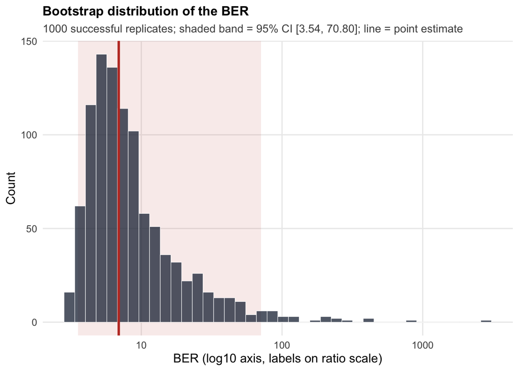

```r
plot_boot(boot1)
```

# 5 第三步：三区分类 `ber_classify()` 与 `bf_classify()`

`ber_classify()`（BER 尺度）与 `bf_classify()`（BAF 尺度）把点估计与置信区间归入 bias-dominated / mixed / effect-dominated 三区。两者在数学上等价，只是输入尺度不同。

```r
# BER 尺度分类：输入 BER 点估计 + BER 的 CI 上下限
cls_ber <- ber_classify(est1$ber, boot1$ci_lo, boot1$ci_hi)
cls_ber
```

```
[1] "bias-dominated"
```

```r
# BAF 尺度分类：输入 BAF 自助中位数 + BAF 的 CI 上下限
cls_bf <- bf_classify(boot1$bf_median, boot1$bf_ci_lo, boot1$bf_ci_hi)
cls_bf
```

```
[1] "bias-dominated"
```

# 6 第四步：Fieller 置信集 `bf_fieller()` 与 `fieller()`

BAF 是比值 $\mu_B / \tilde\psi$ 的单调变换。当分母（校准后存活效应）接近 0 时，普通 Wald 置信区间会失真。`bf_fieller()` 给出该比值的 Fieller 置信集，`fieller()` 是其基础版本。

```r
# 需要 ber_analyze 的拟合对象来提取经验零假设与校准效应
fit1 <- ber_analyze(
  logRr     = t1_logRr,
  seLogRr   = t1_se,
  ncLogRr   = nc_logRr,
  ncSeLogRr = nc_seLogRr,
  ncNames   = nc_names,
  nBoot     = 1000,
  seed      = 42
)
bf_fieller(fit1)
```

```
$lo
[1] -1.74792

$hi
[1] 2.84666

$region
[1] "exterior"
```

```r
fieller(fit1)
```

```
$lo
[1] -1.74792

$hi
[1] 2.84666

$region
[1] "exterior"
```

# 7 第五步：留一法敏感性分析 `ber_loo()`

`ber_loo()` 每次剔除一个阴性对照，重新拟合经验零假设并重算 BAF，检验结论是否依赖某一个阴性对照。

```r
loo1 <- ber_loo(
  logRr     = t1_logRr,
  seLogRr   = t1_se,
  ncLogRr   = nc_logRr,
  ncSeLogRr = nc_seLogRr,
  ncNames   = nc_names,
  nBoot     = 200,
  seed      = 1
)
loo1
```

```
              excluded      ber    ci_lo     ci_hi classification
1       Hyperlipidemia 6.000971 3.294354  99.80630 bias-dominated
2               Anemia 6.743433 3.476329  65.72389 bias-dominated
3  Acute kidney injury 8.860446 3.889433 184.77130 bias-dominated
4  Atrial fibrillation 5.417157 3.087424  24.43834 bias-dominated
5            Pneumonia 6.323678 3.188125  49.29016 bias-dominated
6          Hypotension 7.056732 3.550031 161.65216 bias-dominated
7          Tachycardia 5.922162 3.465234  67.48794 bias-dominated
8       Fluid overload 9.547138 3.811153 638.38483 bias-dominated
9    COPD exacerbation 9.540768 3.706540 146.50114 bias-dominated
10              Sepsis 6.008542 3.309482 173.66803 bias-dominated
11   Venous thrombosis 6.275299 3.417614  65.23573 bias-dominated
12        Hypoglycemia 9.030102 4.105281  91.17538 bias-dominated
```

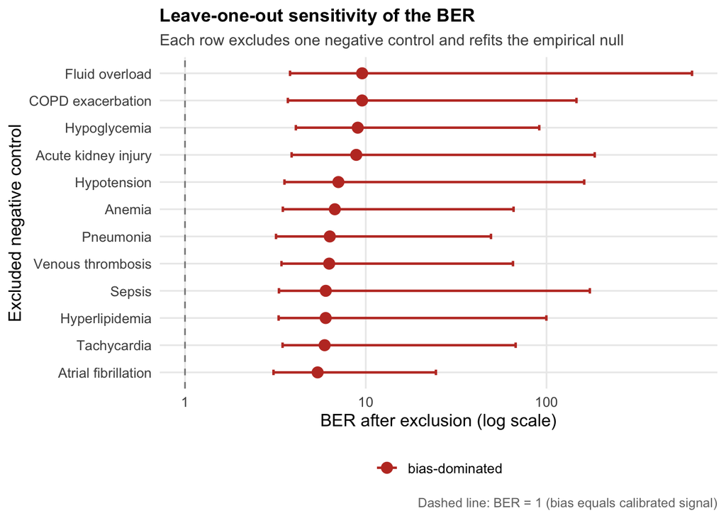

```r
plot_loo(loo1)
```

# 8 第六步：诊断 `ber_diagnostics()`

`ber_diagnostics()` 检验经验零假设的正态性假设：标准化残差、Shapiro-Wilk 检验、以及用于 Q-Q 图的数据。

```r
diag1 <- ber_diagnostics(
  ncLogRr   = nc_logRr,
  ncSeLogRr = nc_seLogRr,
  ncNames   = nc_names
)
cat("Shapiro-Wilk p 值 :", round(diag1$shapiro_p, 4), "\n")
```

```
Shapiro-Wilk p 值 : 0.0729
```

```r
cat("最大标准化残差    :", round(diag1$max_resid, 3),
    " (", diag1$max_resid_name, ")\n", sep = "")
```

```
最大标准化残差    :-1.485 (Fluid overload)
```

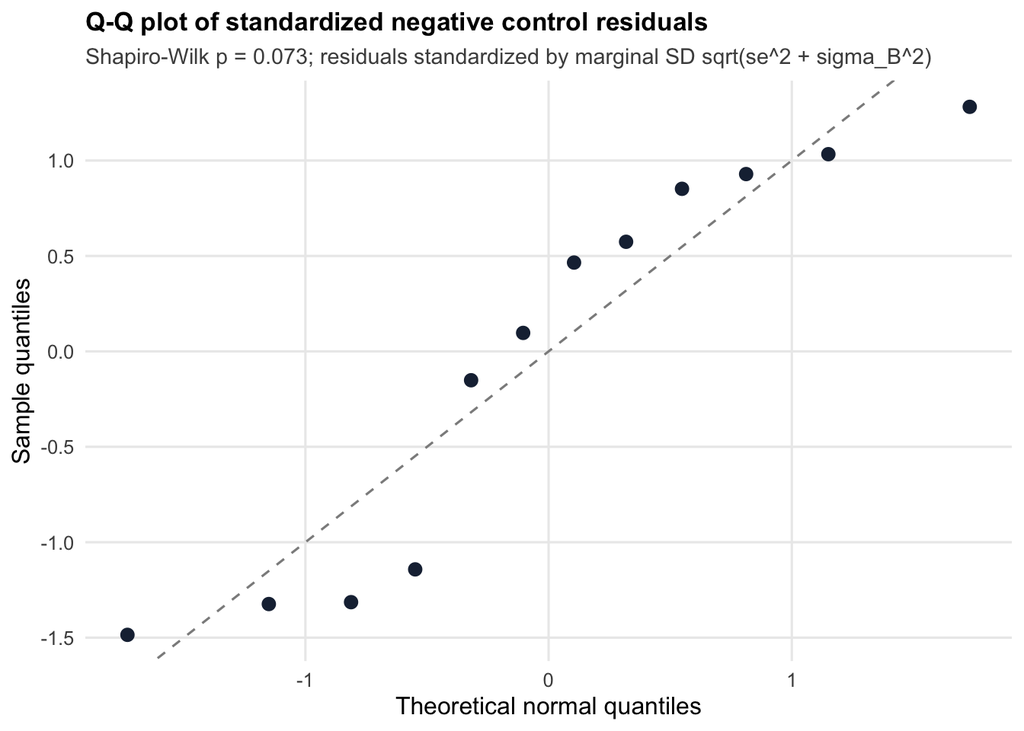

```r
plot_qq(diag1)
```

**解读。** Shapiro-Wilk p 值用于判断 12 个阴性对照的偏差是否近似正态。p 值较大（如 0.073）时不拒绝正态性，支持经验零假设的正态假定。Q-Q 图中点越贴近参考线，越说明残差来自同一正态总体。`max_resid_name` 指出偏离最大的阴性对照，便于人工复核。

# 9 第七步：一体化分析流水线 `ber_analyze()`

`ber_analyze()` 把上述步骤（拟合、Bootstrap、分类、诊断、可选留一法）合并为一次调用，返回 `biasratio` 对象。

```r
print(fit1)
```

```
biasratio: full BER analysis
========================================================
Empirical null:  mu_B = -0.210, sigma_B = 0.041  (K = 12 negative controls)
BAF  = 0.876  |  BER = 7.04
Uncalibrated:    RR = 0.835 [0.765, 0.912],  p < 0.001
Calibrated:      RR = 1.031,  calibrated p 0.617
BER = 6.91,  95% CI [3.54, 70.80]  (log bootstrap, n = 1000)
Classification (CI-based):  bias-dominated
Diagnostics: Shapiro-Wilk p = 0.073; max |std. resid| = -1.49 (Fluid overload)
```

接着给出两张核心诊断图。其一是零假设图，把主估计（菱形）与 12 个阴性对照（点）放在同一坐标轴上：

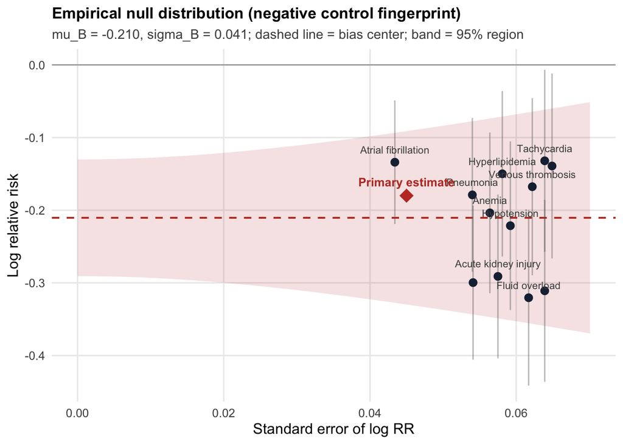

```r
plot_null(est1)
```

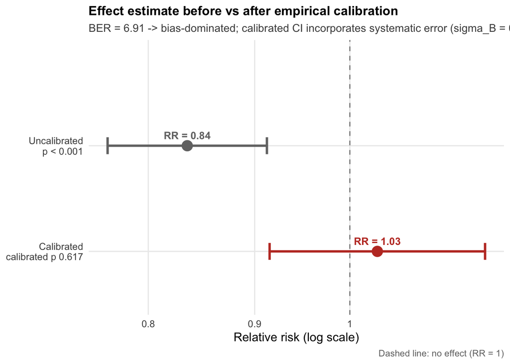

```r
plot_calibration(est1)
```

当主估计的菱形落在阴性对照云团内部（如本例），正是 bias-dominated 关联的视觉特征：主估计与”无因果效应的对照”无法区分。

# 10 第八步：两层筛查 `ber_screen()` 与 `bf_screen()`

当需要对许多暴露-结局对批量判断”该估计能否作为效应证据”时，用 `ber_screen()`（或 BER 尺度的别名 `bf_screen()`）。它执行两层规则：

1. **第一层（信号是否存在）**：校准 p 值须低于阈值（默认 0.05）。否则判定为 `insufficient-evidence`，不进入第二层。
2. **第二层（偏倚占比）**：在确有信号的前提下，依据 BAF 点估计与其 95% CI 的宽度，在参考校准表 `bf_reliability` 中查表得到”真实情形为 bias-dominated”的概率 P(bias-dominated)（取窄 CI 与宽 CI 两种查表的保守最大值），再按固定区间给出判定：< 0.15 为 effect-evidence，0.15-0.45 为 mixed / hypothesis-generating，0.45-0.65 为 competitive / inconclusive，≥ 0.65 为 not-effect-evidence。`explain()` 给出该判定的通俗解释。

对策略 A（已拟合的 `fit1` 对象），直接传入即可复用其 Bootstrap：

```r
sc1 <- ber_screen(fit1)
sc1
```

[output not shown]

```r
cat("\nexplain(sc1):\n")
```

```
explain(sc1):
```

```r
cat(explain(sc1), "\n")
```

[output not shown]

**解读（策略 A）。** 因为校准 p 值 = 0.617 高于 0.05，第一层未通过，判定为 *insufficient-evidence*（证据不足）。注意这与第三步的 bias-dominated 并不矛盾：三区分类只看 BAF 的置信区间（不论校准 p），而两层筛查要求先有真实信号。本例的未校准关联几乎全由偏倚构成，校准后效应近 0，因此”没有可据以判断偏倚占比的真实信号”，恰当结论是证据不足，而非”偏倚主导的有效效应”。

对策略 B（默认方法，重新拟合）：

```r
sc2 <- ber_screen(
  logRr     = t2_logRr,
  seLogRr   = t2_se,
  ncLogRr   = nc_logRr,
  ncSeLogRr = nc_seLogRr,
  ncNames   = nc_names,
  nBoot     = 1000,
  seed      = 42
)
sc2
```

[output not shown]

```r
cat("\nexplain(sc2):\n")
```

```
explain(sc2):
```

```r
cat(explain(sc2), "\n")
```

[output not shown]

**解读（策略 B）。** 策略 B 的校准 p 值低于 0.05，第一层通过，进入第二层。`bf_reliability` 查表给出 P(bias-dominated) = 0.502，落在 competitive / inconclusive 区间（0.45-0.65），判定为 *competitive*。含义是：策略 B 确有超出偏倚的真实信号，但偏倚仍可能占据近一半，尚不足以作为独立效应证据，需要更强阴性对照或更大样本后重筛。

`bf_screen()` 是 `ber_screen()` 的别名，二者输出一致；区别仅在内部以 BER 尺度表达（对习惯比值尺度的读者更直观）。`summary()` 则给出数值化摘要：

```r
summary(sc2)
```

```
              cal_p layer1_pass        bf  bf_ci_lo  bf_ci_hi p_bias_dom
screen 7.484841e-06        TRUE 0.4189844 0.3329365 0.5015952  0.5019284
       verdict_code              verdict_label
screen  competitive COMPETITIVE / INCONCLUSIVE
```

筛查结果的可视化用 `plot()` 调用 `plot.ber_screen` 方法，在 BAF 仪表上标注判定：

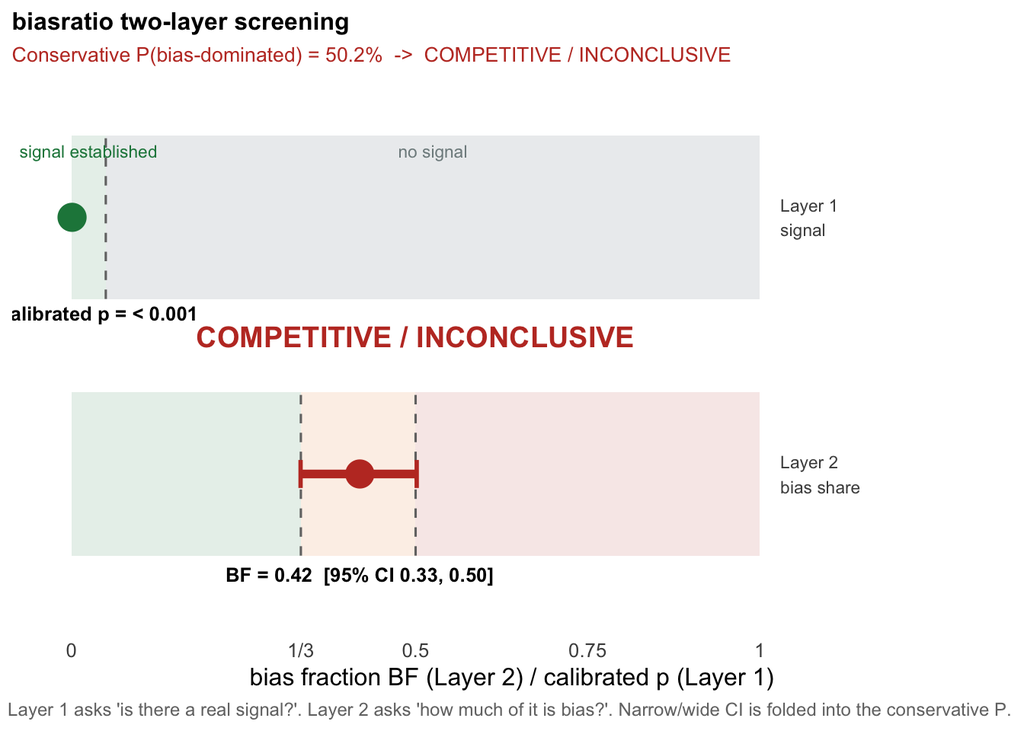

```r
plot(sc2)
```

# 11 可视化函数总览

前面已在各步骤穿插展示了全部绘图函数，这里汇总其用途：

[output not shown]

下面补上 BAF 与 BER 两张仪表（基于 `fit1`），直观对比两种尺度：

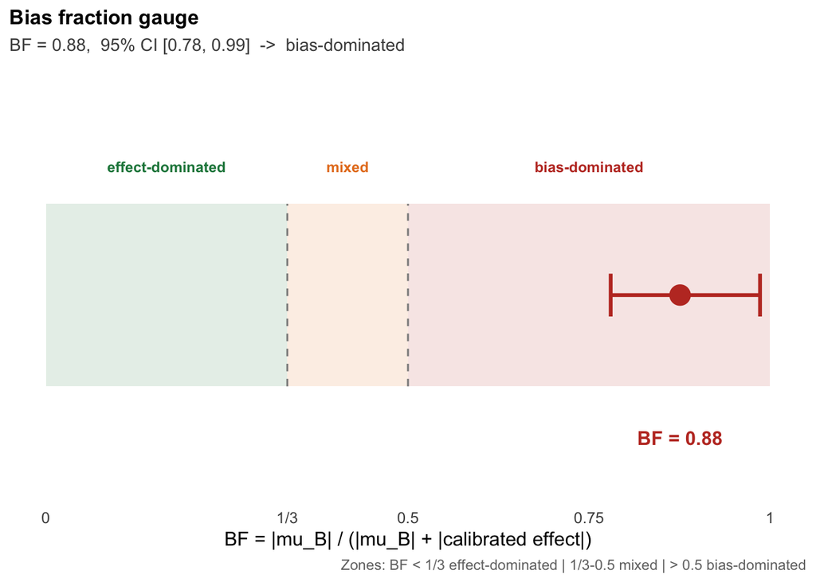

```r
plot_bf_gauge(fit1)
```

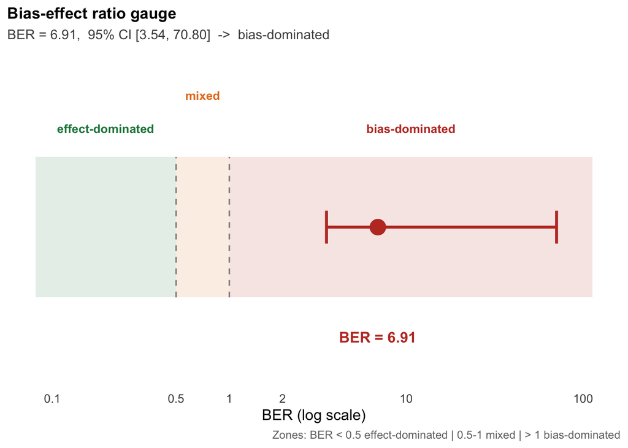

```r
plot_gauge(fit1)
```

BAF 仪表固定 0-1，主估计指针贴近 1 表示信号被偏倚饱和；BER 仪表在比值尺度上，同样的情形下指针会指向很大的数值。论文中推荐优先报告 BAF 仪表，因为它不会因为宽置信区间而把坐标轴压缩变形。

# 12 配色与主题 `ber_pal()` 与 `theme_biasratio()`

`ber_pal()` 返回三区分类的配色（bias-dominated / mixed / effect-dominated），`theme_biasratio()` 是面向临床读者的 ggplot2 主题，可叠加到任意 ggplot 对象上。

```r
# 三区配色
ber_pal()
```

```
  bias-dominated            mixed effect-dominated
       "#C0392B"        "#E67E22"        "#1E8449"
```

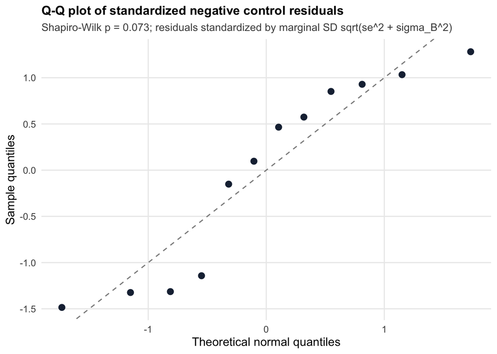

```r
# 把主题叠加到已有图上（以 Q-Q 图为例）
library(ggplot2)
plot_qq(diag1) + theme_biasratio()
```

**解读。** `ber_pal()` 的三种颜色与分类区一一对应，便于在自定义图形中保持视觉一致。`theme_biasratio()` 调整字体、网格与背景，使图形更适合插入临床论文或幻灯片。

# 13 参考校准表 `bf_reliability`

两层筛查第二层依赖的查表来自随包发布的 `bf_reliability`：12 个 BAF 区间、共 960,000 次模拟重复得到的窄/宽 CI 条件下 P(bias-dominated) 的参考值。

```r
data(bf_reliability)
cat("维度 :", nrow(bf_reliability), "行 x", ncol(bf_reliability), "列\n")
```

```
维度 : 12 行 x 3 列
```

```r
cat("中位数 CI 半宽 (med_ci_width) :", round(attr(bf_reliability, "med_ci_width"), 4), "\n")
```

```
中位数 CI 半宽 (med_ci_width) : 0.1299
```

```r
knitr::kable(head(bf_reliability, 6), digits = 4,
             caption = "bf_reliability 前 6 行（12 个 BAF 区间中的前几个）")
```

bf_reliability 前 6 行（12 个 BAF 区间中的前几个）

| bf_center | p_bias_dom_narrow | p_bias_dom_wide |
| --- | --- | --- |
| 0.0927 | 0.0062 | 0.0357 |
| 0.1833 | 0.0110 | 0.0726 |
| 0.2654 | 0.0429 | 0.1386 |
| 0.3337 | 0.1114 | 0.2390 |
| 0.3906 | 0.2449 | 0.3613 |
| 0.4404 | 0.4378 | 0.5019 |

**解读。** `ber_screen()` 默认就读取这张表，用户通常无需直接操作它。当你有自己的模拟校准结果并想替换默认参考时，可把 `reliability` 参数指向自定义数据框（需含 `bf_center`、`p_bias_dom_narrow`、`p_bias_dom_wide` 三列，并带 `med_ci_width` 属性）。

# 14 `bsr_` 别名函数

为兼容早期命名，`biasratio` 提供 `bsr_*` 前缀别名（`bsr_estimate`、`bsr_bootstrap`、`bsr_classify`、`bsr_diagnostics`、`bsr_loo`、`bsr_analyze`），与无前缀版本行为一致。

```r
# 别名与正式函数结果一致
bsr_bf <- bsr_estimate(
  logRr     = t1_logRr,
  seLogRr   = t1_se,
  ncLogRr   = nc_logRr,
  ncSeLogRr = nc_seLogRr,
  ncNames   = nc_names
)$bf
cat("bsr_estimate 的 BAF =", round(bsr_bf, 3),
    "（与 ber_estimate 的", round(est1$bf, 3), "一致）\n")
```

```
bsr_estimate 的 BAF = 0.874 （与 ber_estimate 的 0.874 一致）
```

# 15 综合解读与建议

把上述函数串起来，对这套示例数据可得两条证据链：

- **策略 A（β 受体阻滞剂 ≥50% 目标剂量）**：未校准 RR = 0.835，看似保护性；12 个阴性对照揭示存在保护性系统偏倚（μB ≈ -0.21）。校准后效应近 0（RR ≈ 1.03，校准 p = 0.62），BAF ≈ 0.88 且 95% CI 完全高于 0.5。两层筛查第一层即判 *insufficient-evidence*：没有可据以判断偏倚占比的真实信号。
- **策略 B（完整 GDMT ≥2/3）**：校准后仍留真实信号（校准 p < 0.05），BAF ≈ 0.42，P(bias-dominated) = 0.5，判为 *competitive*。即确有超出偏倚的效应，但偏倚仍可能占近一半，尚不能作为独立效应证据。

给实际使用者的三条建议：

1. 先报校准 p 值与校准 RR，再报 BAF（含 95% CI 与三区），二者回答不同问题，不可替代。
2. 批量筛查时用 `ber_screen()`，让”是否需要更多/更强阴性对照”由第一层自动暴露，而非人工逐条判断。
3. BAF 接近 1 表示信号被偏倚饱和，应解读为”偏倚主导”的定性结论，不要过度解读其精确数值；留一法与 Fieller 分析用于探查结论对个别阴性对照与分母近零情形的稳健性。

完整代码、文档与说明文件已随 `biasratio` v0.3.0 推送至 GitHub（`https://github.com/zengzhechun/biasratio`）。